# grobert_d_ada_hw2

deving

3/28/2021

#CHALLENGE 1 #read in the data

```
f <- "https://raw.githubusercontent.com/difiore/ada-2021-datasets/main/IMDB-movies.csv"
d <- read_csv(f, col_names = TRUE)
```

#filter for movies from the 1920’s- 1970’s between 1 and 3 hrs long

```
d <- filter(d, startYear %in% 1920:1979)
d <- filter(d, runtimeMinutes >= 60 & runtimeMinutes <= 180)
```

#create “decade” variable

```
b<-c(-Inf, 1930, 1940, 1950, 1960, 1970, Inf)
names<-c("twenties", "thirties", "fourties", "fifties", "sixties", "seventies")
d$decade<-cut(d$startYear, breaks=b, labels=names)
```

#plot histogram of the distribution of runtime (in 10 minute bins) for each decade

[output not shown]

#“results” includes population mean and sd of runtime or each decade

```
results<-d %>%
  group_by(decade) %>%
  summarise_at(vars(runtimeMinutes), funs(mean(., na.rm=TRUE), sd(.,              na.rm=TRUE)))
```

#sample of 100 movies from each decade

```
s <- d %>% group_by(decade) %>% sample_n(size=100, replace=FALSE)
```

#sample mean and sd of runtime for each decade

```
s_results<-s %>%
  group_by(decade) %>%
  summarise_at(vars(runtimeMinutes), funs(mean(., na.rm=TRUE), sd(.,              na.rm=TRUE)))
```

#sample standard error of the mean (SEM) for each decade

```
s_results$SEM<-s_results$sd/sqrt(100)
```

#compare sample estimates of sd, m, and SEM with population estimates of same and SE in the pop mean for n=100

```
compare<-inner_join(s_results,results, by = "decade")
compare<-compare%>%
  rename(
  sample_mean = mean.x,
  sample_sd = sd.x,
  sample_se = SEM,
  pop_mean = mean.y,
  pop_sd = sd.y,
  )
compare$pop_se<-compare$pop_sd/sqrt(100)
```

#sampling distribution: 1000 samples of 100 movies from each decade with mean and sd for each sample

```
n<-100
reps <- 1000

samp_dist <-
  do(reps) * d %>%
  group_by(decade) %>%
  sample_n(size=n, replace=FALSE)%>%
  summarise_at(vars(runtimeMinutes), funs(mean(., na.rm=TRUE), sd(.,              na.rm=TRUE)))
```

#mean and sd of sample means for each decade

```
samp_dist_results_mean<-samp_dist %>%
  group_by(decade) %>%
  summarise_at(vars(mean), funs(mean(., na.rm=TRUE)))

samp_dist_results_sd<-samp_dist %>%
  group_by(decade) %>%
  summarise_at(vars(mean), funs(sd(., na.rm=TRUE)))

samp_dist_results<-inner_join(samp_dist_results_mean, samp_dist_results_sd, by="decade")

samp_dist_results<-samp_dist_results%>%
  rename(
  dist_mean=mean.x,
  dist_sd=mean.y)
```

#histograms of the sampling distributions for each decade

[output not shown]

#compare SE from each decade from initial sample, from known pop, and from samp distribution of means

```
compare_all<-inner_join(compare,samp_dist_results, by = "decade")

compare_all$dist_se<-compare_all$dist_sd/sqrt(1000)
```

#CHALLENGE 2 #probability that the bee biologist sees 9 bees or fewer

[output not shown]

#probability that the bee biologist sees 0 bees

```
ppois(0, lambda=12)
```

#probability that she sees exactly 5 bees

```
dpois(5, lambda=12)
```

#probability that she sees more than 18

```
ppois(18, lambda=12, lower=FALSE)
```

[output not shown]

#simulate 1460 results

```
s<-rpois(1460, 12)
```

#plot simulation

```
s_plot<-histogram(s,
    type = "density",
    main = paste("Histogram of Outcomes of ", 1460, " Bee Sessions", sep = ""),
    xlab = "count",
    ylab = "Probability",
    xlim = 0:24
  )
```

#CHALLENGE 3 #read in zombie data

```r
z <- "https://raw.githubusercontent.com/difiore/ada-2021-datasets/master/zombies.csv"
d <- read_csv(z, col_names = TRUE)
```

#mean for each quantitative variables

```r
m<-c((mean(d$height)), (mean(d$weight)),  (mean(d$age)), (mean(d$zombies_killed)), (mean(d$years_of_education)))
```

#create a function for pop sd

```r
pop.sd <- function(x){sd(x)*sqrt((length(x)-1)/length(x))}
```

#pop sd for quantitative variables

```r
sd <- c((pop.sd(d$height)), (pop.sd(d$weight)),  (pop.sd(d$age)), (pop.sd(d$zombies_killed)), (pop.sd(d$years_of_education)))
```

#boxplots for quantitative variables

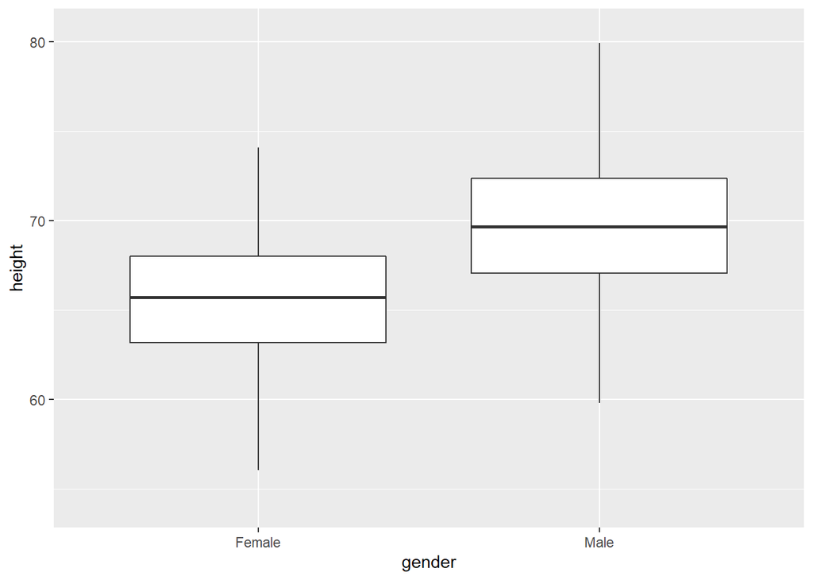

```r
hp <- ggplot(data = d, aes(x = gender, y = height)) +
  geom_boxplot(na.rm = TRUE, outlier.shape = NA)
hp
```

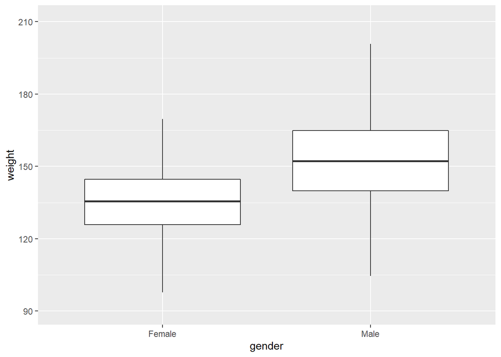

```r
wp <- ggplot(data = d, aes(x = gender, y = weight)) +
  geom_boxplot(na.rm = TRUE, outlier.shape = NA)
wp
```

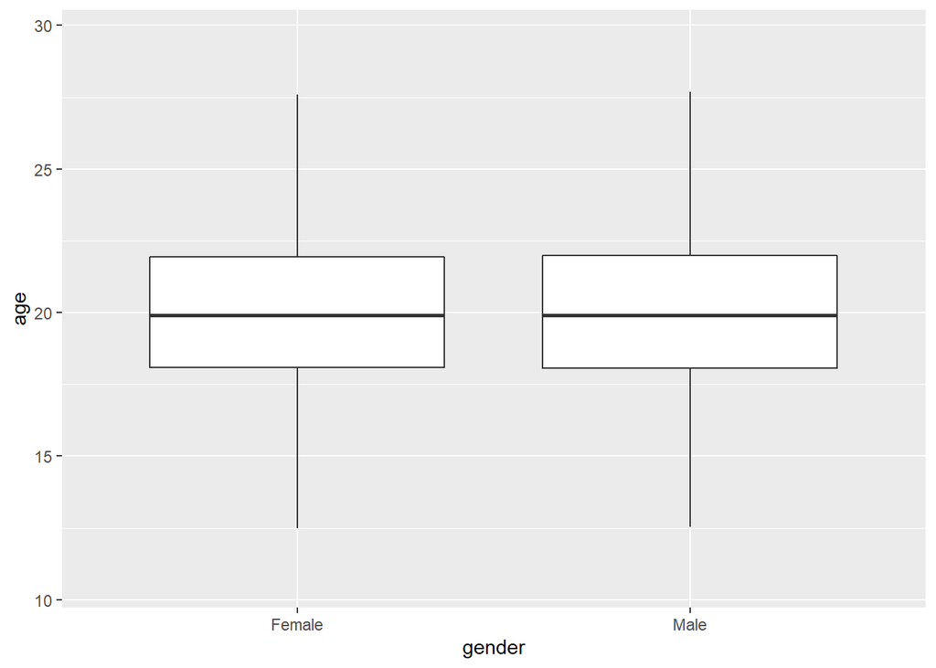

```r
ap <- ggplot(data = d, aes(x = gender, y = age)) +
  geom_boxplot(na.rm = TRUE, outlier.shape = NA)
ap
```

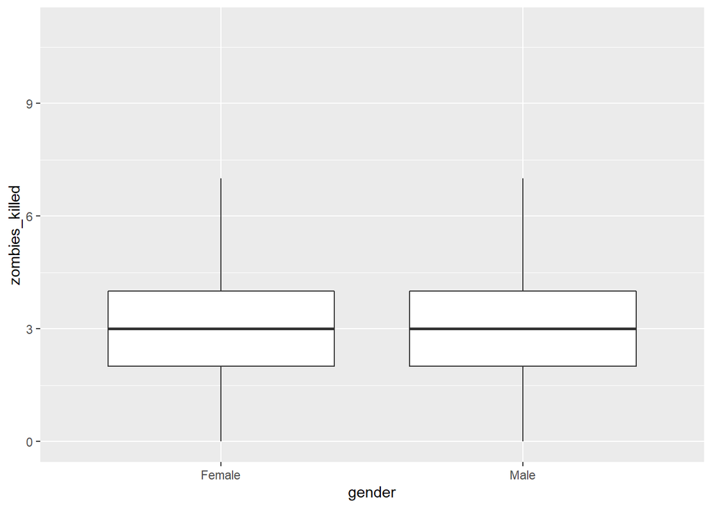

```r
zkp <- ggplot(data = d, aes(x = gender, y = zombies_killed)) +
  geom_boxplot(na.rm = TRUE, outlier.shape = NA)
zkp
```

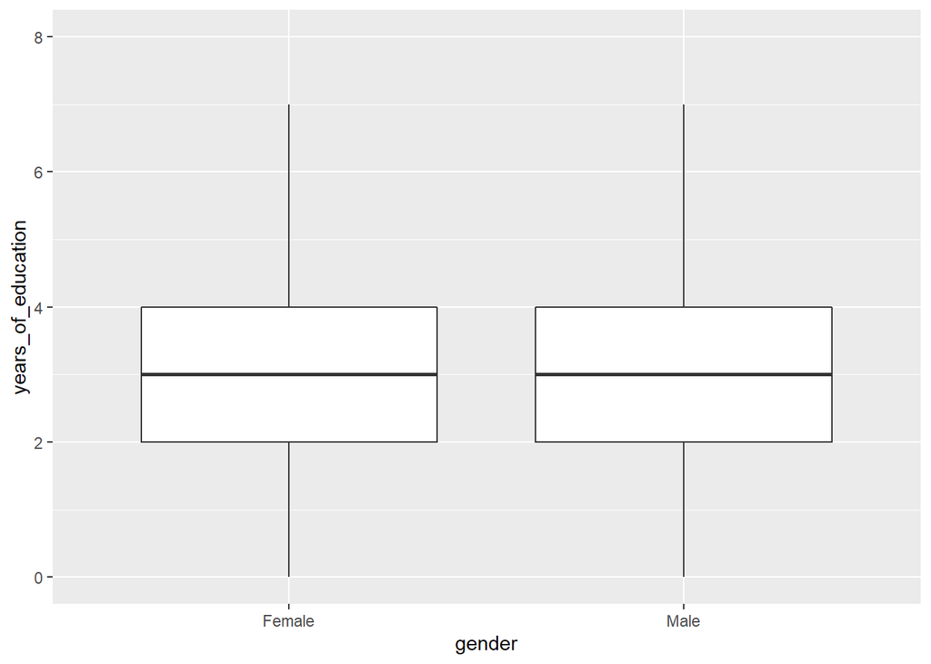

```r
sp <- ggplot(data = d, aes(x = gender, y = years_of_education)) +
  geom_boxplot(na.rm = TRUE, outlier.shape = NA)
sp
```

#scatterplot of height in relation to age, gender by point color

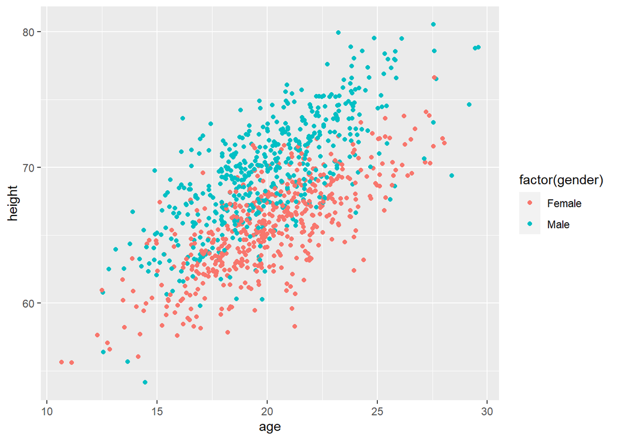

```r
sh <- ggplot(data = d, aes(
  x = age,
  y = height,
  color = factor(gender)
))
sh <- sh + geom_point(na.rm = TRUE)
sh
```

#scatterplots of weight in relation to age, gender by point color

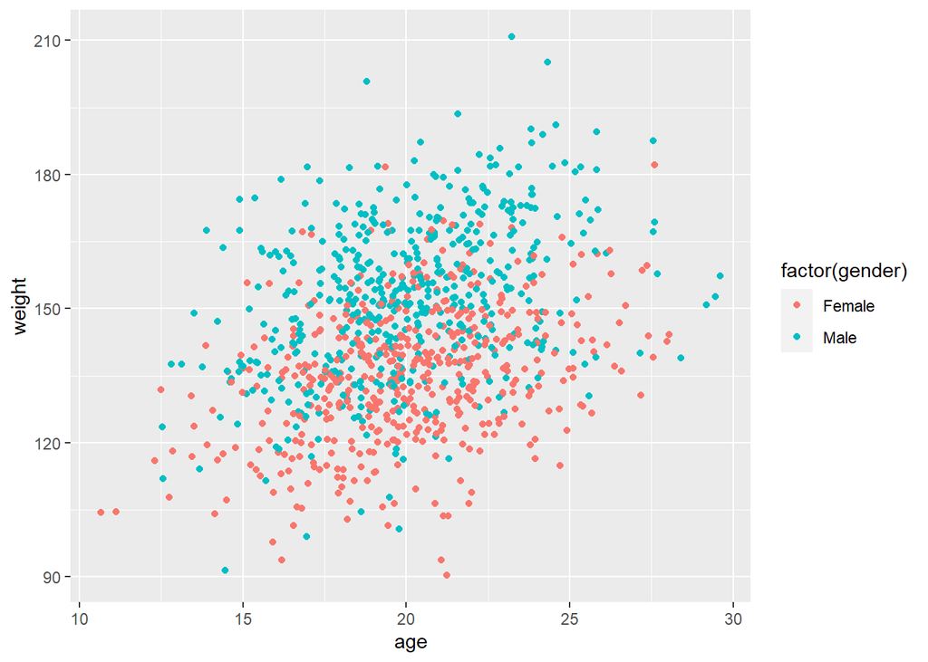

```r
sw <- ggplot(data = d, aes(
  x = age,
  y = weight,
  color = factor(gender)
))
sw <- sw + geom_point(na.rm = TRUE)
sw
```

#both weight and height appear to be positively correlated to age, average values for both appear to be higher for males than females

#qq plot for height

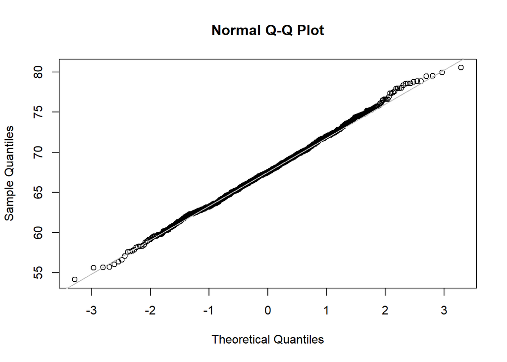

```r
qqnorm(d$height)
qqline(d$height, col = "gray")
```

#histo for height

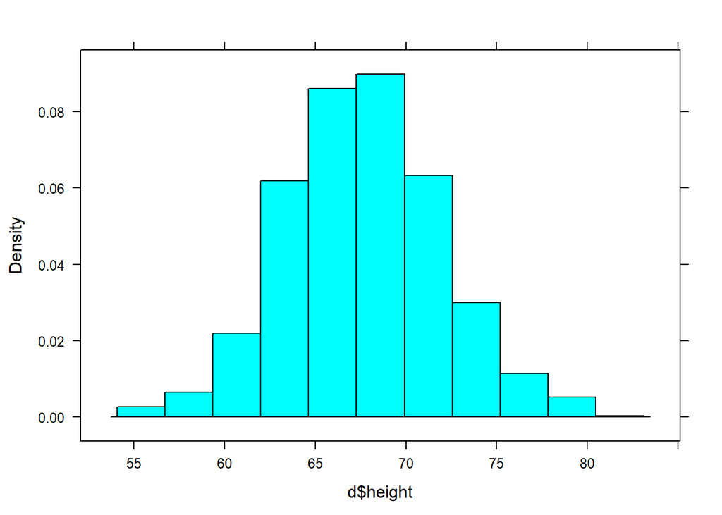

```r
histogram(d$height,
    type = "density",
 )
```

#height looks normal

#qq plot for weight

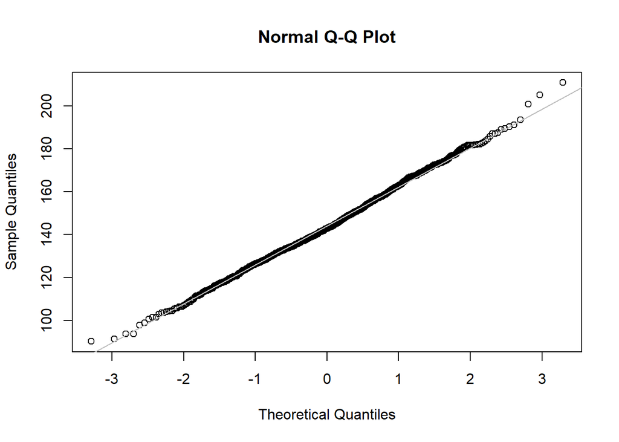

```r
qqnorm(d$weight)
qqline(d$weight, col = "gray")
```

#histo for weight

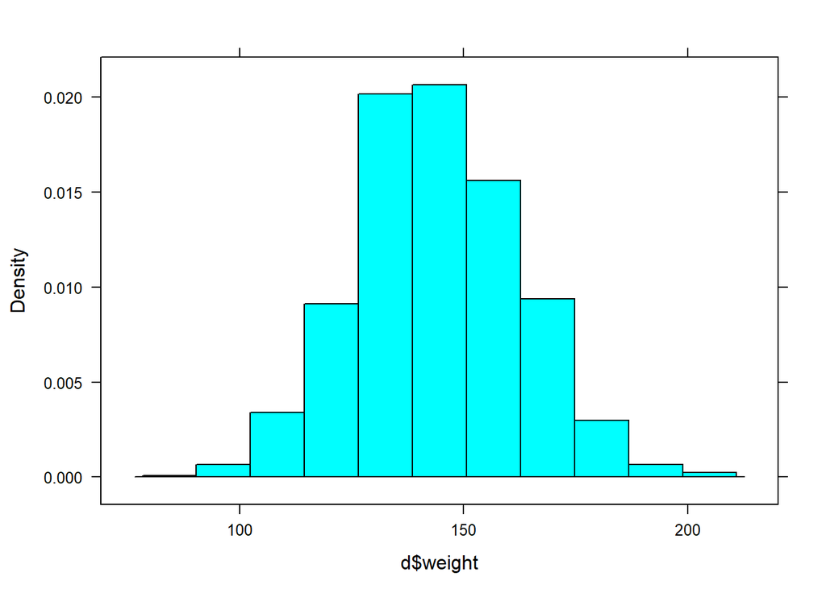

```r
histogram(d$weight,
    type = "density",
 )
```

#weight looks normal

#qq plot for age

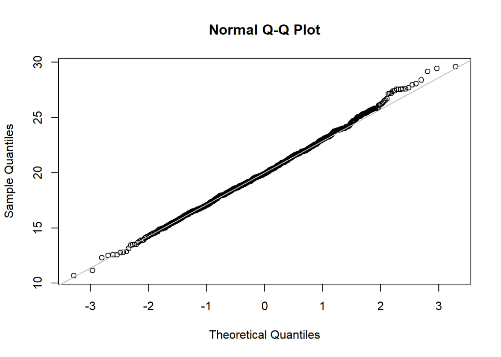

```r
qqnorm(d$age)
qqline(d$age, col = "gray")
```

#histo for age

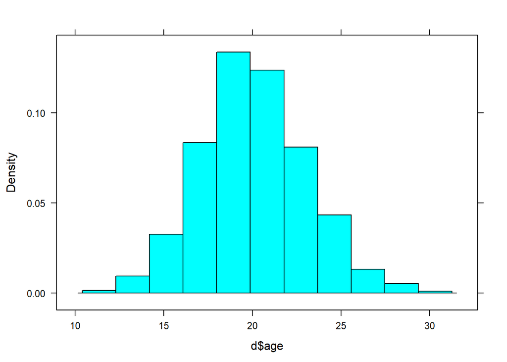

```r
histogram(d$age,
    type = "density",
 )
```

#age looks normal

#qq plot for zombies killed

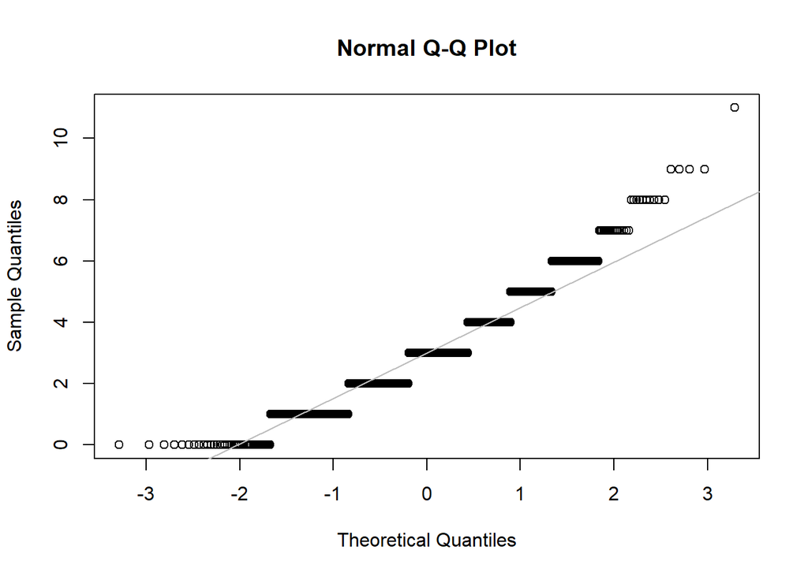

```r
qqnorm(d$zombies_killed)
qqline(d$zombies_killed, col = "gray")
```

#histo for zombies killed

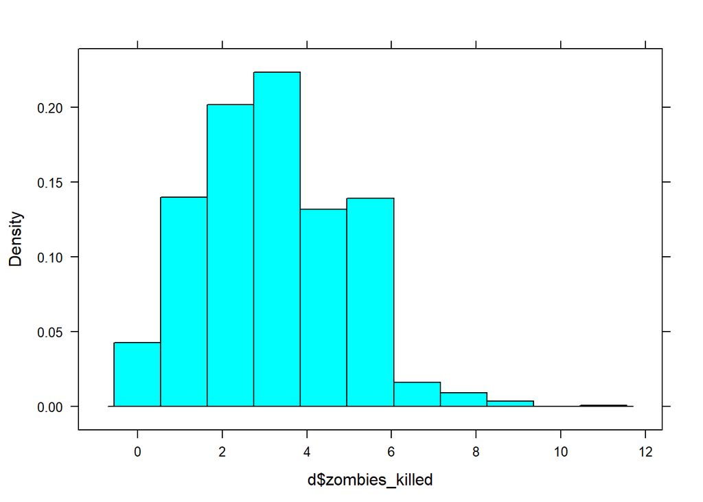

```r
histogram(d$zombies_killed,
    type = "density",
 )
```

#zombies killed NOT normal, looks like binomial